# La Brecha Invisible: Análisis de la carga de cuidados por sexo en España

Impacto del empleo y el servicio doméstico mediante microdatos del INE

Olga Ocaña Mozos

2026-01-19

## 1.Introducción

Este proyecto de investigación analiza cómo el sexo y la situación laboral influyen en la distribución del tiempo dedicado al cuidado de niños en España. A través de los microdatos de la Encuesta de Empleo del Tiempo, exploramos si la externalización de servicios (servicio doméstico) logra mitigar la brecha existente.

## 2. Metodología

Para el análisis se han integrado cuatro fuentes de datos principales:

1. MHOGAR: Variables demográficas y sexo.
2. DIARIO2: Registro de actividades en intervalos de 10 minutos (Código 938: Cuidados de niños).
3. CINDIV: Situación laboral (Ocupados vs. No ocupados).
4. SD: Presencia de servicio doméstico pagado en el hogar.

Los datos se han ponderado utilizando el Factor de Elevación (FACTORF) para representar fielmente a la población española.

## 3. Resultados Principales y Análisis Visual

### 3.1. Volumen Total de Trabajo de Cuidados

El primer análisis compara el total de horas diarias que hombres y mujeres dedican al cuidado infantil, diferenciando si el hogar cuenta con ayuda externa.

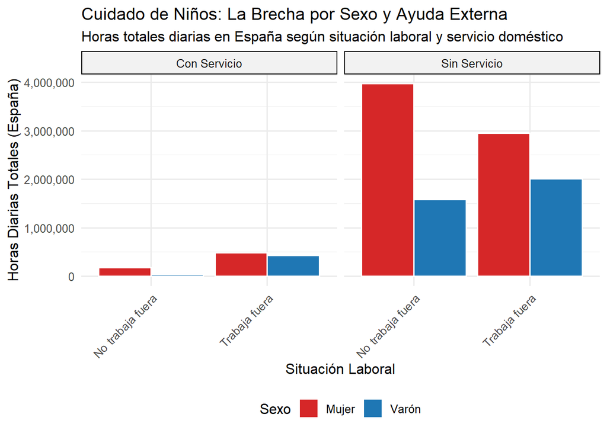

### 3.2. Distribución Horaria (La Carga Mental y Temporal)

A continuación, se muestra el “ritmo” del cuidado a lo largo de las 24 horas del día. Este gráfico de densidad revela los picos de actividad según el sexo.

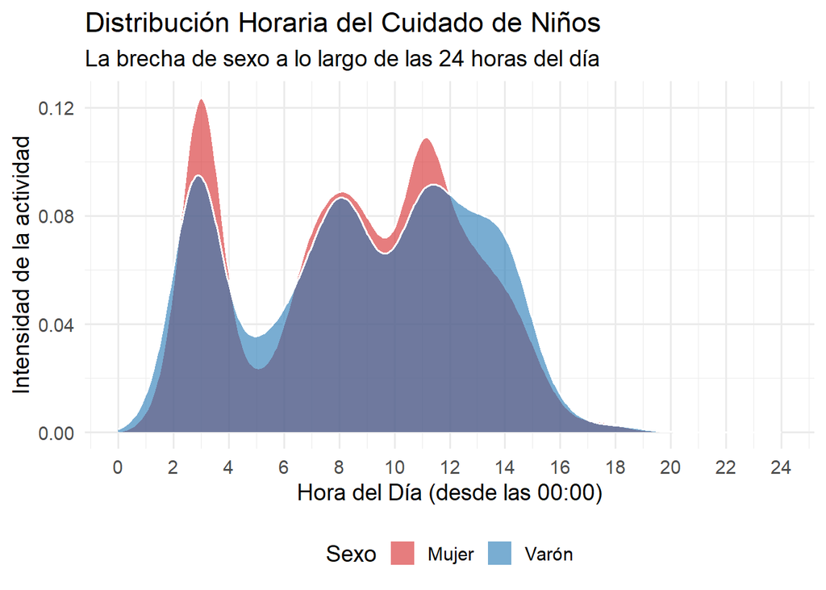

### 3.3. Edad de los cuidadores

¿A qué edades se concentra el esfuerzo del cuidado?

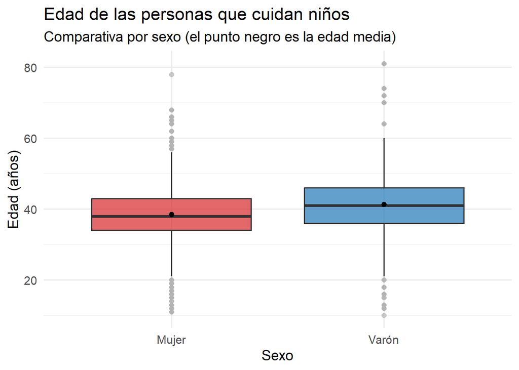

### 3.4. Análisis Estadístico de la Edad

Estadísticos descriptivos de edad por sexo

| SEXO | Edad_Media | Edad_Minima | Edad_Maxima | N_Casos |
| --- | --- | --- | --- | --- |
| Mujer | 38.5 | 11 | 78 | 5970 |
| Varón | 41.3 | 10 | 81 | 2754 |

## 5. Referencias Bibliográficas

- **Instituto Nacional de Estadística (INE).** (2010). *Encuesta de Empleo del Tiempo (EET) 2009-2010. Microdatos y Metodología.* Recuperado de ine.es
- **Metodología de la EET:** El análisis se basa en la clasificación de actividades CINDIV y el registro de diarios (DIARIO2) donde el código **938** corresponde específicamente a ‘Cuidado de niños’.
- **Tratamiento de Datos:** La diferenciación de resultados se ha realizado bajo la premisa de que el **sexo** es la variable biológica y demográfica fundamental que estructura la carga de cuidados en los hogares españoles.